# ESM244 Assignment 2 Task 2: Binary Logistic Regression

Grace Brofman

2/1/2021

In a separate .Rmd saved as a2_task2_firstname_lastname.Rmd, using the Florida palmetto data (palmetto.csv), use binary logistic regression to test feasibility of using variables plant height (height), canopy length (length), canopy width (width), and number of green leaves (green_lvs) to classify whether a palmetto is species Serenoa repens or Sabal etonia. Use code folding and hide all messages & warnings in your knitted HTML.

Data source: Abrahamson, W.G. 2019. Survival, growth and biomass estimates of two dominant palmetto species of south-central Florida from 1981 - 2017, ongoing at 5-year intervals ver 1. Environmental Data Initiative. https://doi.org/10.6073/pasta/f2f96ec76fbbd4b9db431c79a770c4d5

More information and metadata: https://portal.edirepository.org/nis/metadataviewer?packageid=edi.317.1

```r
library(tidyverse)
library(ggfortify)
library(viridis)
library(RColorBrewer)
library(hrbrthemes)
library(patchwork)
library(here)
```

```r
library(tidyverse)
library(GGally) # for pairs plots
library(broom) # for tidy model outputs in dataframes
library(jtools) # to make quick graphs of model outputs

palmetto <- read_csv(here("data", "palmetto.csv"))
```

### Section 1: Explore the differences in height, canopy length, canopy width, and green leaves for the two species. Add a figure caption to each. Below each data visualization, add a short (~1 sentence) statement with a takeaway from the visualization.

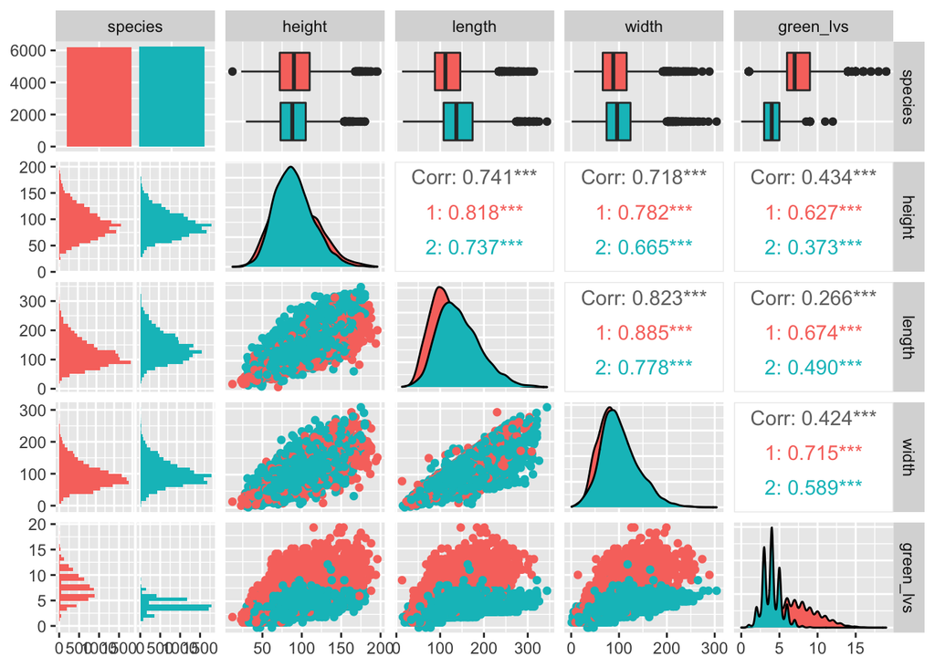

```r
# according to metadata, 1 (in species column) refers to "Serenoa repens" and 2 refers to "Sabal etonia"
# see metadata for all other column/variable specifications

palmetto_explore <- palmetto %>%
  select(species, height, length, width, green_lvs) %>%
  mutate(species = as.factor(species))  # changing species classification from character to factor

palmetto_explore %>%
  ggpairs(aes(color = species))
```

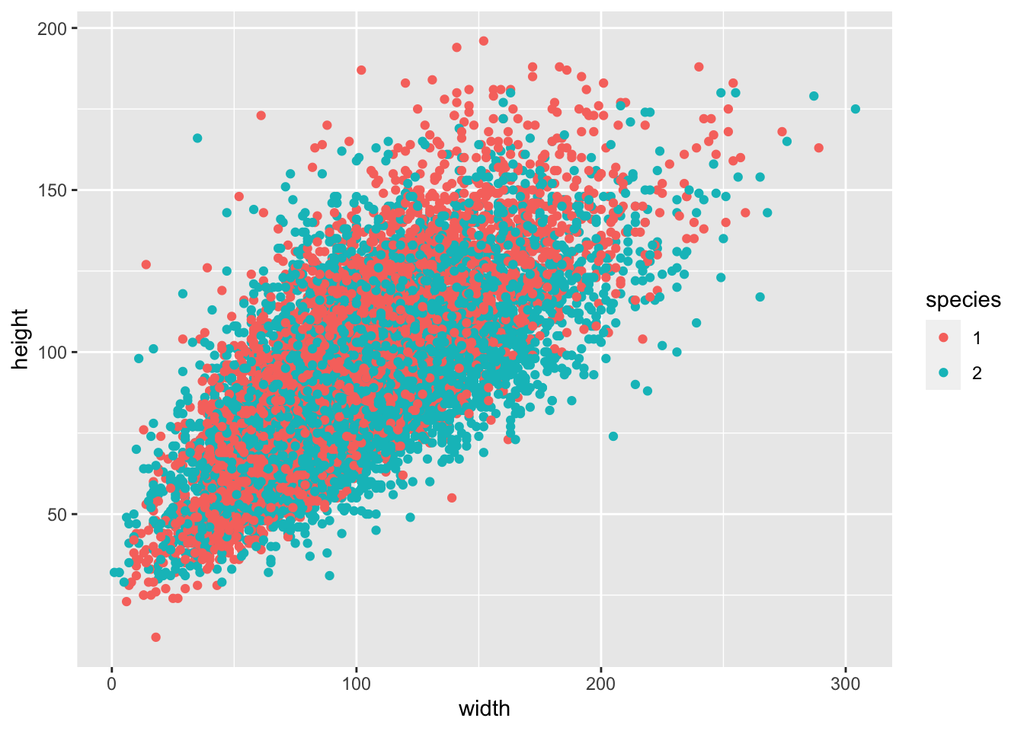

```r
# pairs plots show lots of similarity in height and width, and the most visible difference in green leaves followed by length

# visualizing width and height by species
ggplot(data = palmetto_explore,
       aes(x = width,
           y = height)) +
  geom_point(aes(color = species))
```

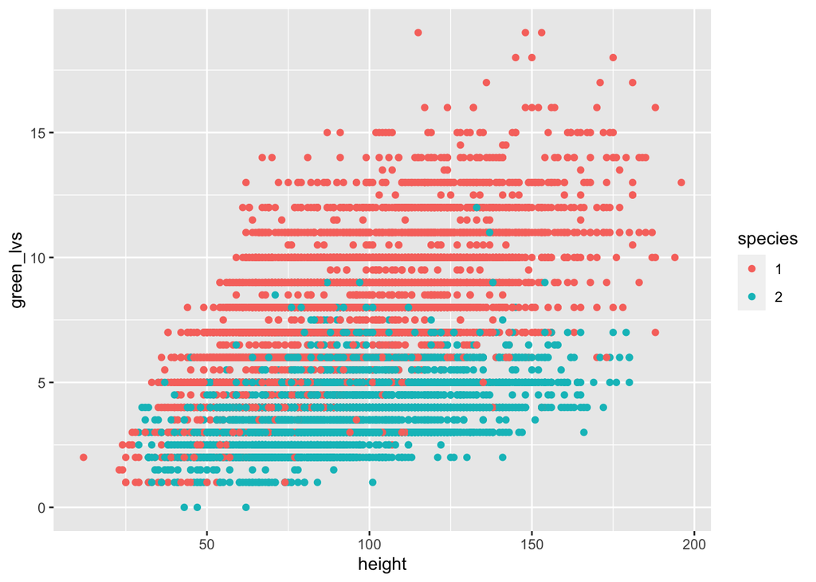

```r
# appears to be lots of overlap between the species for height/width

# visualizing height and green leaves by species
ggplot(data = palmetto_explore,
       aes(x = height,
           y = green_lvs)) +
  geom_point(aes(color = species))
```